# Arbitrary-precision linear algebra in R using RcppEigen and BH

## Motivation

## Floating-point arithmetic

Computers hold a finite amount of precision by using (binary) scientific notation.

- Which can lead to counter-intuitive results.

```r
# NOTE: You should really use all.equal!
(0.1 + 0.2) == 0.3
```

```
## [1] FALSE
```

## But what if I need more precision?

**Arbitrary-precision arithmetic**

- Useful when dealing with very large numbers (e.g. cryptography)
- But inherently slower

*Note*: Whenever possible, use a more accurate fixed-precision algorithm

## Eigenvalues of Wishart matrices

\(W \sim W_p(n, \Sigma) \Rightarrow W = X^TX,\) \(X(i,) \sim N_p(0, \Sigma), i=1,\ldots,n.\)

- Chiani (JMA, 2014) gave an exact algorithm for computing the CDF of the largest eigenvalue of \(W\).

## Chiani’s algorithm

1. Using iterative rules, construct a skew-symmetric matrix \(A\) of dimension \(\approx \min(n,p)\).
2. Compute \(\sqrt{\det(A)}\).
3. Divide by normalization constant.

**Problem**: For \(n,p\) large, both the determinant and the normalization constant are large.

## Solution

## Existing `R` packages

Some of the available options:

- `gmp` and `Rmpfr`: Link to C/C++ libraries
- `Ryacas`: Interfaces with a Computer Algebra System

## Boost via `BH`

> “Boost provides free peer-reviewed portable C++ source libraries.”
- `BH` allows `R` users to work with these libraries.

```cpp
#include <boost/multiprecision/cpp_dec_float.hpp>

using namespace boost::multiprecision;

// Define new type with 100-digit precision
typedef number<cpp_dec_float<100>> mp_float;
```

## `RcppEigen`

> “Eigen is a C++ template library for linear algebra”
- Templates mean that you can do linear algebra with user-defined types!

```cpp
#include <Eigen/Dense>

Eigen::Matrix<mp_float,100,1> vec;

// Compute dot product
mp_float dot = vec.dot(vec);
```

## Example

## `rootWishart`: n=25, p=15, fixed precision

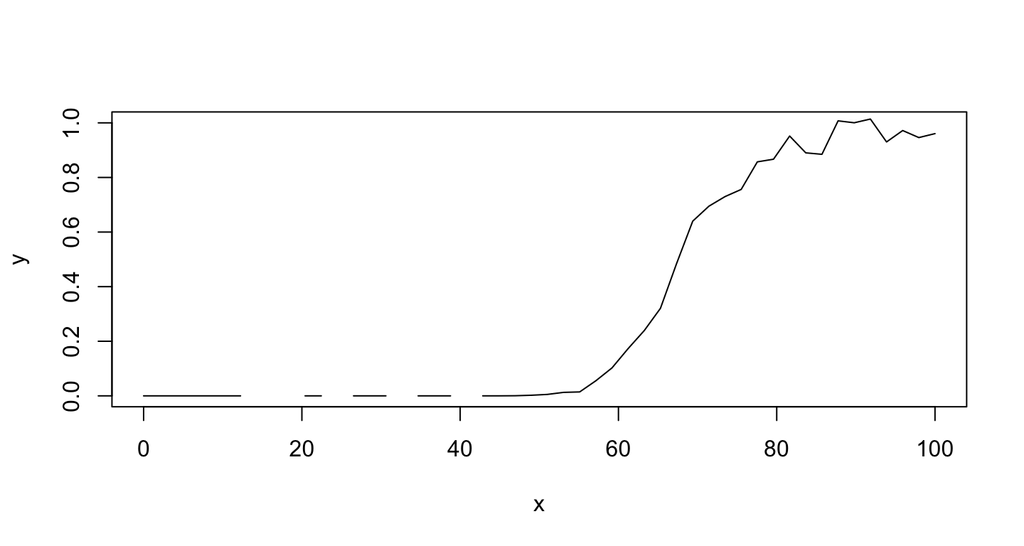

Non-monotonic curve

```r
x <- seq(0, 100, length.out = 50)
y <- rootWishart::singleWishart(x, p=15, n=25,
                                type="fixed")
plot(x, y, type = 'l', ylim = c(0,1))
```

## `rootWishart`: n=25, p=15, arbitrary precision

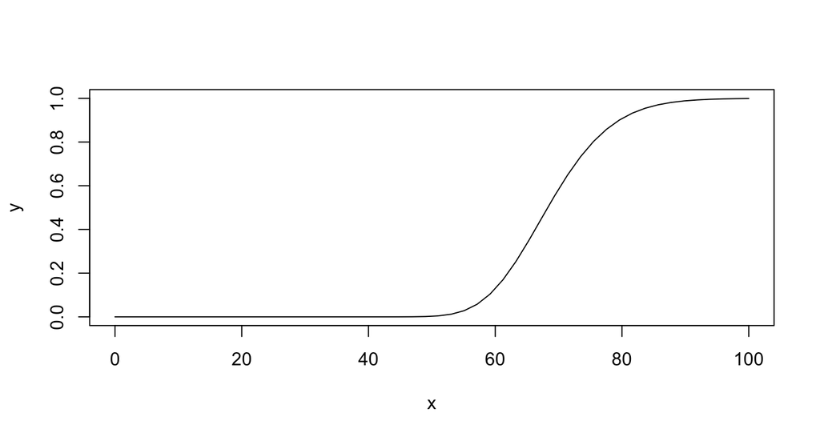

Monotonically increasing, as expected

```r
x <- seq(0, 100, length.out = 50)
y <- rootWishart::singleWishart(x, p=15, n=25,
                                type="arbitrary")
plot(x, y, type = 'l', ylim = c(0,1))
```

## Conclusion

- The combination of `BH` and `RcppEigen` provides a lot of flexibility.
- The cost is slower algorithms and the need to code in `C++`
- Chiani (2016) proposed a similar algorithm for double Wishart problems, also implemented in `rootWishart`
- **General rule**: More precise algorithms > arbitrary precision